# Solutions Module 6: Simple Linear Regression

# Linear Regression Models

**Definition**

A **linear model** is a regression model in which the regression coefficients enter the model linearly. For example:

$$Y = \beta_0 + \beta_1 X_1 + \beta_2 X_2 + \ldots + \beta_p X_p + \epsilon . \tag{2}$$

The model does not need to be linear in predictor variables:

$$Y = \beta_0 + \beta_1 X_1^2 + \beta_2 e^{X_2+X_3^2} + \beta_3 \ln{(X_1X_2X_3)} + \epsilon$$

The $\beta_i$’s are called the **regression coefficients**, and these are unknown parameters we will estimate.

- A **simple linear regression model** has one predictor, $Y = \beta_0 + \beta_1 X + \epsilon$.
- A **multiple linear regression model** has more than one predictor variable.

# Simple Linear Regression

The **simple linear regression** is a linear regression model with a single predictor $X$ and a single response variable $Y$. It does not refer to the complexity of the linear model. The most common simple linear regression model is the familiar

$$Y = \beta_0 + \beta_1 X + \epsilon .$$

The response variable $Y$:

- Is treated as a **random variable**.
- We can observe values (denoted $y_i$) of $Y_i$ at each observation $x_i$ in our sample.
- We estimate the mean value of $Y_i$ with $\hat{y}_i = \hat{\beta}_0 + \hat{\beta}_1 x_i$.

The predictor variable $X$.

- Is treated as a **fixed (non-random)** and **observable** value.
- Does not need to be predicted or estimated.

The regression coefficients $\beta_0$ and $\beta_1$:

- Are **unknown parameters** that we will estimate from our sample data.
- Are treated as **fixed (non-random)** but **not observable** values.
- Most commonly estimated using OLS that are denoted $\hat{\beta}_0$ and $\hat{\beta}_1$.

The error $\epsilon$ is the deviation of the response from its mean. It does not imply the model has a *mistake* or *malfunction*. The error is:

- Treated as a **random variable** that is not observable, and
- Assumed to have $E(\epsilon) = 0$ (the model is not biased).
- The errors of prediction are random and not equal to the **residuals** that we can use as estimates.

## Why Do We Use Random Variables?

Let’s consider a simple linear regression model (with one predictor) of the form $Y = \beta_0 + \beta_1 X + \epsilon$. It is very possible different observations in the population can have the same value for the predictor, $X=x_i$, but have different values of the response variable, we denote $Y_i$.

- Two different animals could have the same body mass but different brain mass.
- That is why we consider each $Y_i$ a random variable. It’s value varies due to randomness in sampling.
- We cannot describe how $Y_i$ is distributed without having population data.

The model gives the same prediction for each observations with $X=x_i$, namely $\widehat{y}_i = \hat{\beta}_0 + \hat{\beta}_1 x_i$; however, the observed values of $y_i$ when $X=x_i$ will vary. Thus:

- The each error of prediction $\epsilon_i$ is considered a random variable.
- We cannot describe how each $\epsilon_i$ is distributed without having population data.

## Error Assumptions

A simple linear regression model of the form $Y = \beta_0 + \beta_1 X + \epsilon$ has the following key assumptions about the errors of prediction:

- **Linearity**: $Y$ and $X$ have a linear relationship. In other words, the mean value of $Y$ is a straight-line function of $X$. If the have a nonlinear association, we should modify our model or transform predictor and/or response variables.

$$E(Y | X=x_i) = \beta_0 + \beta_1 x_i$$

- **Mean Zero**: We do not want our model to be biased.

$$E(\epsilon_i) = E(\epsilon | X=x_i) = 0 \qquad \text{for all } x_i.$$

- **The Errors are Uncorrelated**: The error in one prediction does not effect the amount of error in any other prediction.

$$\text{Cov}(\epsilon_i, \epsilon_j ) = 0 \qquad \text{for all } i \ne j .$$

- **Homoscedasticity**: The model is equally accurate everywhere. Thus, the errors of prediction have the same, constant variance. We do not want the model to be more accurate when $x$ is small and less accurate when $x$ is large.

$$\text{Var}(\epsilon_i) = \text{Var}(\epsilon | X = x_i) = \sigma^2 \qquad \text{for all } x_i .$$

- **Normality**: The errors are normally distributed. Most observations of $Y_i$ are close to the prediction $\hat{Y}_i$, and we are less and less likely to observe values $Y_i$ farther and farther away from the prediction.

We can summarize several of the assumptions on $\epsilon_i$ as follows. For all $\epsilon_i$ and $\epsilon_j$, we have

$$\large \epsilon_i \sim N(0, \sigma^2) \qquad \text{and} \qquad \text{Cov}(\epsilon_i, \epsilon_j) = 0 \ \ \text{ if } i \ne j.$$

## Estimating $\sigma^2$, the Variance of the Errors

In the error assumptions, we denote the parameter for the error variance as $\sigma^2$. The error variance is a parameter describing the unknown distribution of prediction errors, $\epsilon$, which are random variables. We can use the residuals to estimate the error variance, denoted $\hat{\sigma}^2$, using the following formula:

$$\hat{\sigma}^2 = \frac{SSE}{n-p} = \frac{RSS}{n-p}$$

- The RSS and SSE are two different names for the same thing.
- $n$ is the number of observations in the sample.
- $p$ is the number of predictors, *which includes the intercept*.
- The denominator $n-p$ is the **degrees of freedom** of the RSS.
- For simple linear regression (one predictor), we have $p=2$ and $df = n-2$.

$$\text{Special case for simple linear regression:} \qquad\hat{\sigma}^2 = \frac{RSS}{n-2}$$

```r
# calculating the variance of all residuals
var(residuals(lmod_brain2))
```

```
[1] 30038.77
```

```r
# computing RSS / (n-2)
n <- nrow(mammals_clean)
sum(residuals(lmod_brain2)^2) / (n - 2)
```

```
[1] 30556.68
```

```r
# using functions from lm output
deviance(lmod_brain2)  # RSS of the model
```

```
[1] 1772288
```

```r
df.residual(lmod_brain2) # degrees of freedom for RSS
```

```
[1] 58
```

```r
sigma(lmod_brain2) # st dev deviation of the errors
```

```
[1] 174.8047
```

```r
(sigma(lmod_brain2))^2 # variance of the errors
```

```
[1] 30556.68
```

## Question 6

Compute the estimate for the variance of the errors for the `wind` and `pressure` model you constructed earlier (stored in `lmod_wind`).

## Checking Error Assumptions

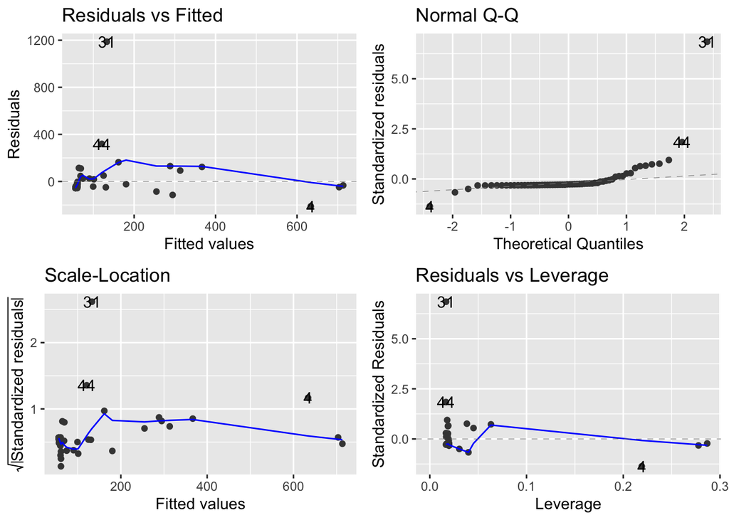

```r
#library(ggfortify)
autoplot(lmod_brain2)
```

**Tip**

We will discuss how to read and utlize each of the plots below to assess and improve linear models. [Here’s a nice summary](https://rpubs.com/Amrabdelhamed611/669768) if you cannot wait!

## Question 7

Use the `autoplot()` function from `ggfortify` to create plots associated to the residuals. How do some of the assumptions seem to check out?